# Title: “Assignment 2-Impact of Weather Events on Human Well-Being”

## SYNOPSIS

#### Weather events is the US cause multiple fatalities and hundreds of injuries in the US. The U.S. National Oceanic and Atmospheric Administration’s (NOAA) colects data on the type of weather events related to either a death or an injury. The following research is aimed at discovering the type of events, impact, and frequencie in the US.

## DATA PROCESSING

Raw data from NOAA can be dowloaded from https://d396qusza40orc.cloudfront.net/repdata%2Fdata%2FStormData.csv.bz2 After setting directory to local drive, read csv file using read.csv

```r
  echo = TRUE
    setwd("C:/Users/ivan/Desktop/datasciencecoursera/ReResearch")
         data <- read.csv("repdata_data_StormData.csv.bz2")
```

This research will use ggplot2 and plyr libraries. Load libraries:

```r
            library(ggplot2)
                library(plyr)
```

Explore data by summarizing fields

```r
   summary (data)
```

```
##     STATE__                  BGN_DATE             BGN_TIME
##  Min.   : 1.0   5/25/2011 0:00:00:  1202   12:00:00 AM: 10163
##  1st Qu.:19.0   4/27/2011 0:00:00:  1193   06:00:00 PM:  7350
##  Median :30.0   6/9/2011 0:00:00 :  1030   04:00:00 PM:  7261
##  Mean   :31.2   5/30/2004 0:00:00:  1016   05:00:00 PM:  6891
##  3rd Qu.:45.0   4/4/2011 0:00:00 :  1009   12:00:00 PM:  6703
##  Max.   :95.0   4/2/2006 0:00:00 :   981   03:00:00 PM:  6700
##                 (Other)          :895866   (Other)    :857229
##    TIME_ZONE          COUNTY           COUNTYNAME         STATE
##  CST    :547493   Min.   :  0.0   JEFFERSON :  7840   TX     : 83728
##  EST    :245558   1st Qu.: 31.0   WASHINGTON:  7603   KS     : 53440
##  MST    : 68390   Median : 75.0   JACKSON   :  6660   OK     : 46802
##  PST    : 28302   Mean   :100.6   FRANKLIN  :  6256   MO     : 35648
##  AST    :  6360   3rd Qu.:131.0   LINCOLN   :  5937   IA     : 31069
##  HST    :  2563   Max.   :873.0   MADISON   :  5632   NE     : 30271
##  (Other):  3631                   (Other)   :862369   (Other):621339
##                EVTYPE         BGN_RANGE           BGN_AZI
##  HAIL             :288661   Min.   :   0.000          :547332
##  TSTM WIND        :219940   1st Qu.:   0.000   N      : 86752
##  THUNDERSTORM WIND: 82563   Median :   0.000   W      : 38446
##  TORNADO          : 60652   Mean   :   1.484   S      : 37558
##  FLASH FLOOD      : 54277   3rd Qu.:   1.000   E      : 33178
##  FLOOD            : 25326   Max.   :3749.000   NW     : 24041
##  (Other)          :170878                      (Other):134990
##          BGN_LOCATI                  END_DATE             END_TIME
##               :287743                    :243411              :238978
##  COUNTYWIDE   : 19680   4/27/2011 0:00:00:  1214   06:00:00 PM:  9802
##  Countywide   :   993   5/25/2011 0:00:00:  1196   05:00:00 PM:  8314
##  SPRINGFIELD  :   843   6/9/2011 0:00:00 :  1021   04:00:00 PM:  8104
##  SOUTH PORTION:   810   4/4/2011 0:00:00 :  1007   12:00:00 PM:  7483
##  NORTH PORTION:   784   5/30/2004 0:00:00:   998   11:59:00 PM:  7184
##  (Other)      :591444   (Other)          :653450   (Other)    :622432
##    COUNTY_END COUNTYENDN       END_RANGE           END_AZI
##  Min.   :0    Mode:logical   Min.   :  0.0000          :724837
##  1st Qu.:0    NA's:902297    1st Qu.:  0.0000   N      : 28082
##  Median :0                   Median :  0.0000   S      : 22510
##  Mean   :0                   Mean   :  0.9862   W      : 20119
##  3rd Qu.:0                   3rd Qu.:  0.0000   E      : 20047
##  Max.   :0                   Max.   :925.0000   NE     : 14606
##                                                 (Other): 72096
```

[output cut: 41 more lines]

```
##  Min.   :   0   Min.   :-14451   Min.   :   0   Min.   :-14455
##  1st Qu.:2802   1st Qu.:  7247   1st Qu.:   0   1st Qu.:     0
##  Median :3540   Median :  8707   Median :   0   Median :     0
##  Mean   :2875   Mean   :  6940   Mean   :1452   Mean   :  3509
##  3rd Qu.:4019   3rd Qu.:  9605   3rd Qu.:3549   3rd Qu.:  8735
##  Max.   :9706   Max.   : 17124   Max.   :9706   Max.   :106220
##  NA's   :47                      NA's   :40
##                                            REMARKS           REFNUM
##                                                :287433   Min.   :     1
##                                                : 24013   1st Qu.:225575
##  Trees down.\n                                 :  1110   Median :451149
##  Several trees were blown down.\n              :   568   Mean   :451149
##  Trees were downed.\n                          :   446   3rd Qu.:676723
##  Large trees and power lines were blown down.\n:   432   Max.   :902297
##  (Other)                                       :588295
```

For simplicity, after reviewing existing fields, we created a new dataset with only those fields relevant to this research: EvType, Fatalities, Injuries, Propdmg and Cropdmg. Remove rows where there are no readings (all fields =0) for the different types (EVTYPE)

```r
  keyfields <- c("EVTYPE", "FATALITIES", "INJURIES", "PROPDMG", "CROPDMG")
      data <- data[, keyfields]
          data<- data[!(data$FATALITIES == 0 & data$INJURIES == 0 & data$PROPDMG == 0 & data$CROPDMG == 0), ]
```

**Data ready for calculation**

## RESULTS

We treated death and injuries separately. We first focused on death by creating a table aggregating the number of deaths by weather event (EVTYPE)

```r
  death <- aggregate(data$FATALITIES ~ data$EVTYPE, FUN = sum)
     death2 <- death[complete.cases(death), ]
        colnames(death2) <- c("type", "deaths")
            death2 <- death2[order(death2$death, decreasing = TRUE), ]
                 death2 <- death2[!(death2$death == 0), ]
                       head(death2)
```

```
##               type deaths
## 407        TORNADO   5633
## 61  EXCESSIVE HEAT   1903
## 73     FLASH FLOOD    978
## 151           HEAT    937
## 258      LIGHTNING    816
## 423      TSTM WIND    504
```

**Tornados are the main caused of weather related deaths (5,633) in the US followed by Excessive Heat (1,903) and Flash Floods (978)**

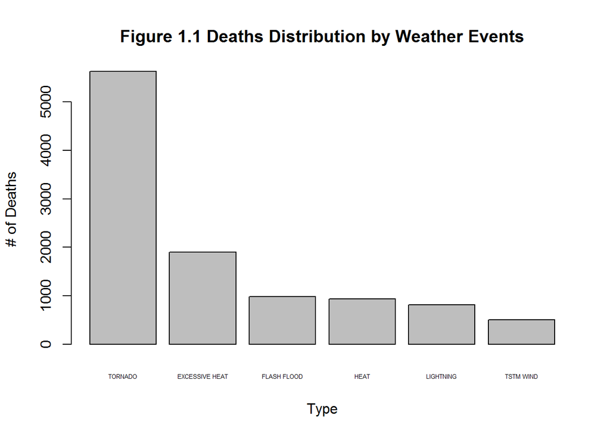

```r
barplot(head(death2$deaths), names.arg = head(death2$type), main = "Figure 1.1 Deaths Distribution by Weather Events", ylab = "# of Deaths", xlab = "Type", cex.names = 0.4)
```

**Non lethal events may also cause a great deal of damage and phisical trauma to humans. We continued by looking at injuries to humans very much in the same way we looked at deaths.**

```r
injurie <- aggregate(data$INJURIES ~ data$EVTYPE, FUN = sum)
    injurie2 <- injurie[complete.cases(injurie), ]
        colnames(injurie2) <- c("Type", "Injuries")
            injurie2 <- injurie2[order(injurie2$Injuries, decreasing = TRUE), ]
                injurie2 <- injurie2[!(injurie2$Injuries == 0), ]
                head(injurie2)
```

```
##               Type Injuries
## 407        TORNADO    91346
## 423      TSTM WIND     6957
## 86           FLOOD     6789
## 61  EXCESSIVE HEAT     6525
## 258      LIGHTNING     5230
## 151           HEAT     2100
```

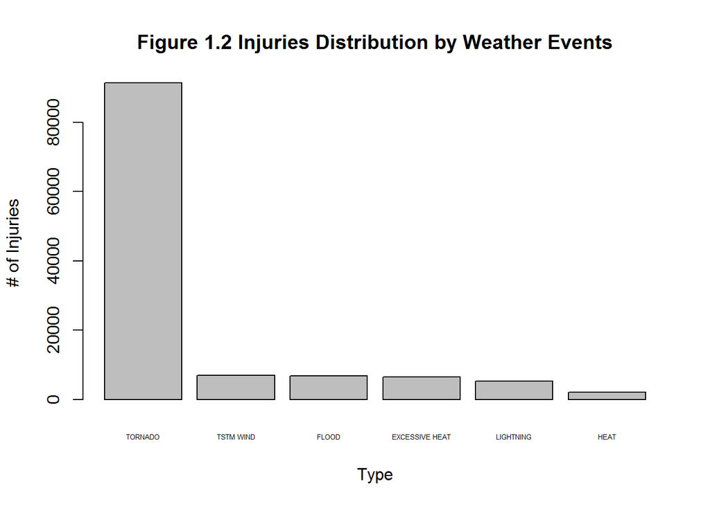

```r
barplot(head(injurie2$Injuries), names.arg = head(injurie2$Type), main = "Figure 1.2 Injuries Distribution by Weather Events", ylab = "# of Injuries", xlab = "Type", cex.names = 0.4)
```

**Damaged caused by weather events is not limited to physical damange to human. These events cause millions of dollars in damage to personal property, crops and the overall economic activity. The economic consequences of these events can be devastating for a region and even for the nation as a whole.**

```r
eco <- aggregate(data$PROPDMG ~ data$EVTYPE, FUN = sum)
    eco2 <- eco[complete.cases(eco), ]
        colnames(eco2) <- c("Type", "EconomicDamage")
            eco2 <- eco2[order(eco2$EconomicDamage, decreasing = TRUE), ]
                eco2 <- eco2[!(eco2$EconomicDamage == 0), ]
                    head(eco2)
```

```
##                  Type EconomicDamage
## 407           TORNADO      3212258.2
## 73        FLASH FLOOD      1420124.6
## 423         TSTM WIND      1335965.6
## 86              FLOOD       899938.5
## 364 THUNDERSTORM WIND       876844.2
## 134              HAIL       688693.4
```

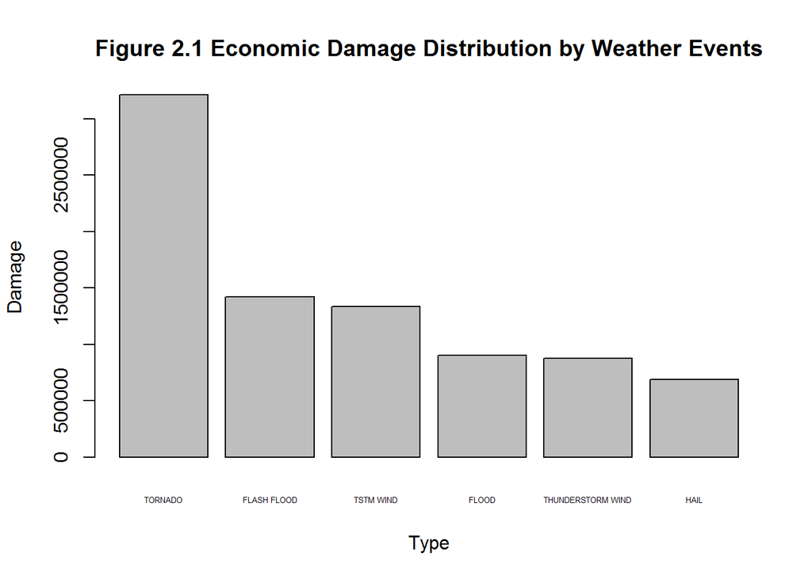

```r
barplot(head(eco2$EconomicDamage), names.arg = head(eco2$Type), main = "Figure 2.1 Economic Damage Distribution by Weather Events", ylab = "Damage", xlab = "Type", cex.names = 0.4)
```

**Figure 2.1 continues to show that tornados are devastating weather events at both physical and economical levels. We also see that some non-life threating events such as Hail can have devastating economic consequences for the US.**